# Coronavirus v Čechách

# Základní statistiky

## Testy

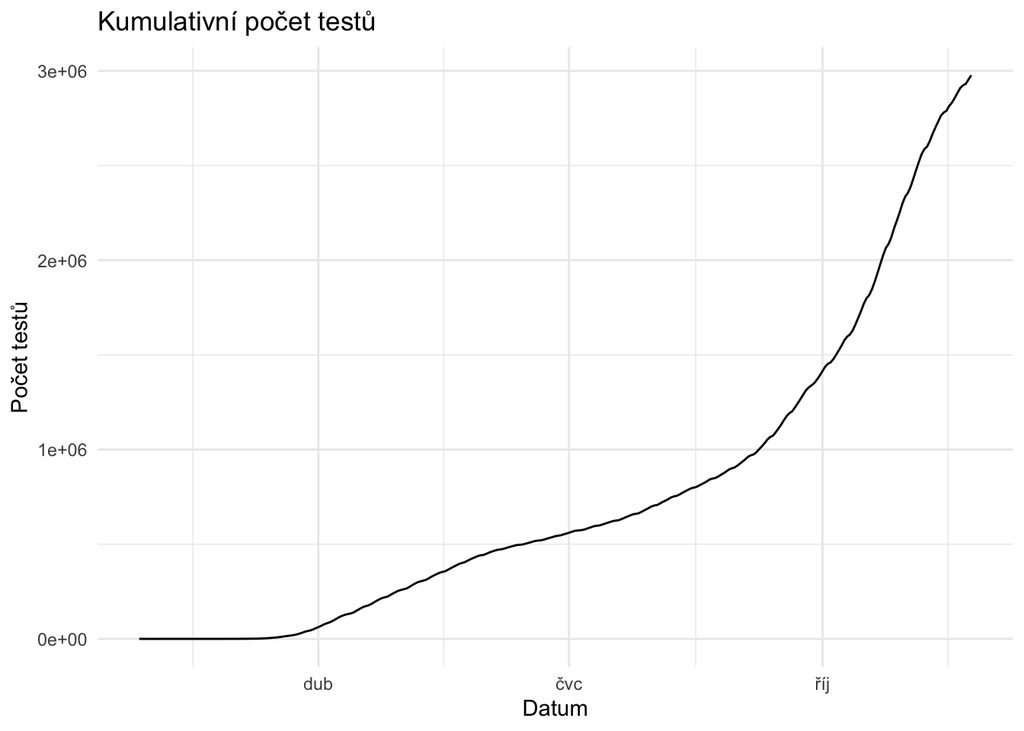

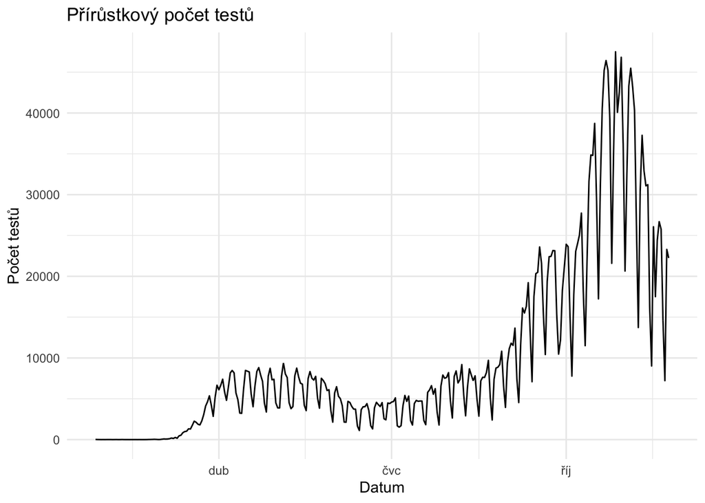

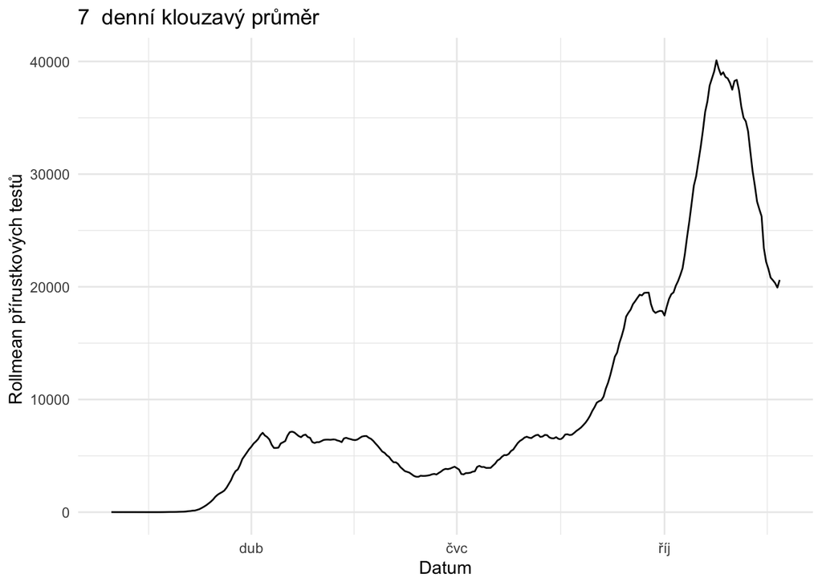

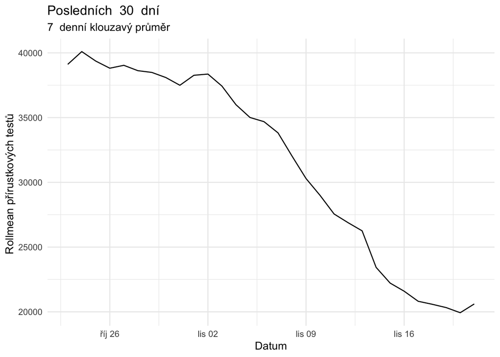

## Pozitivní případy

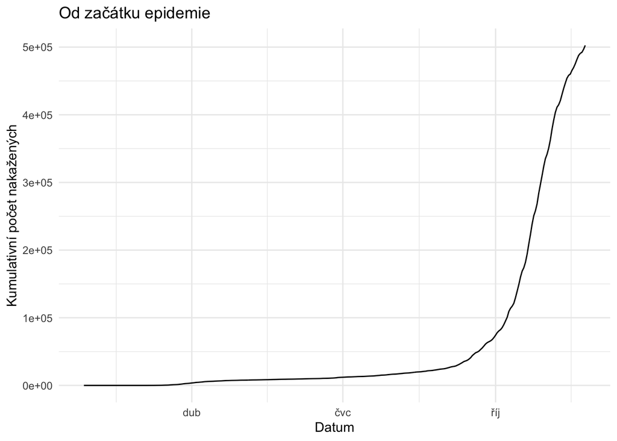

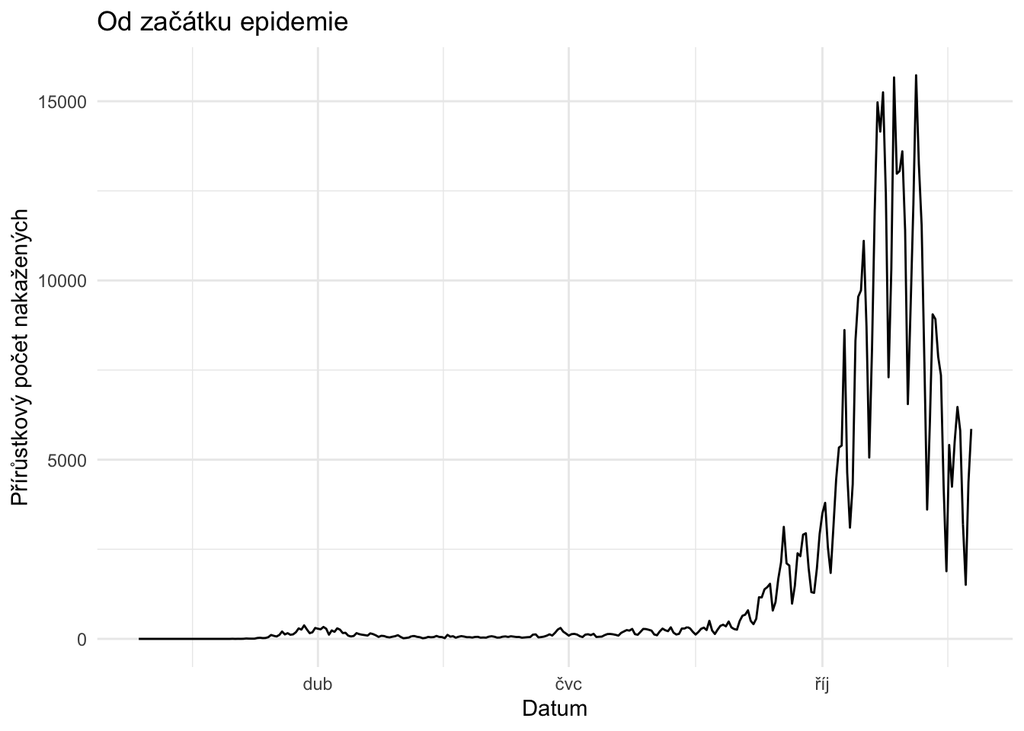

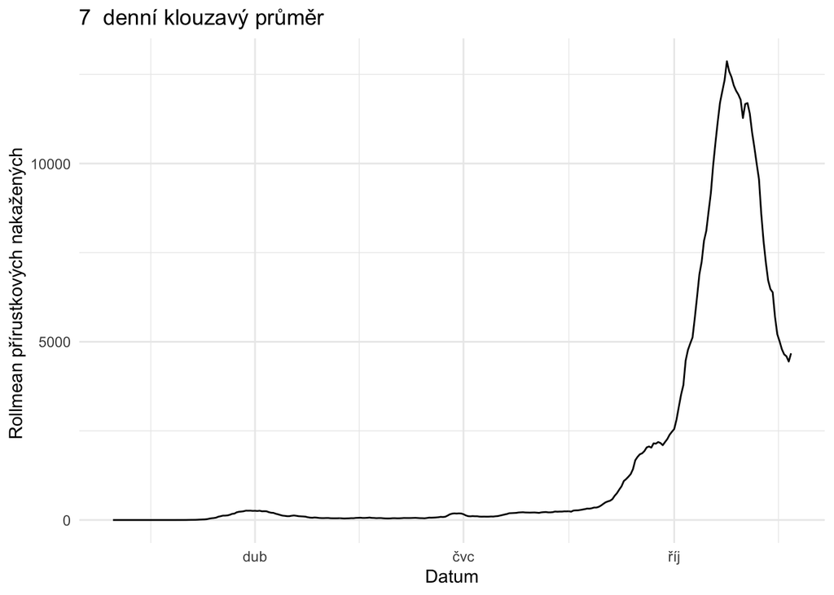

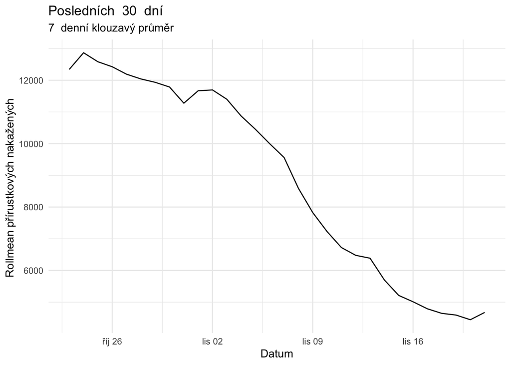

## Podíl pozitivních testů

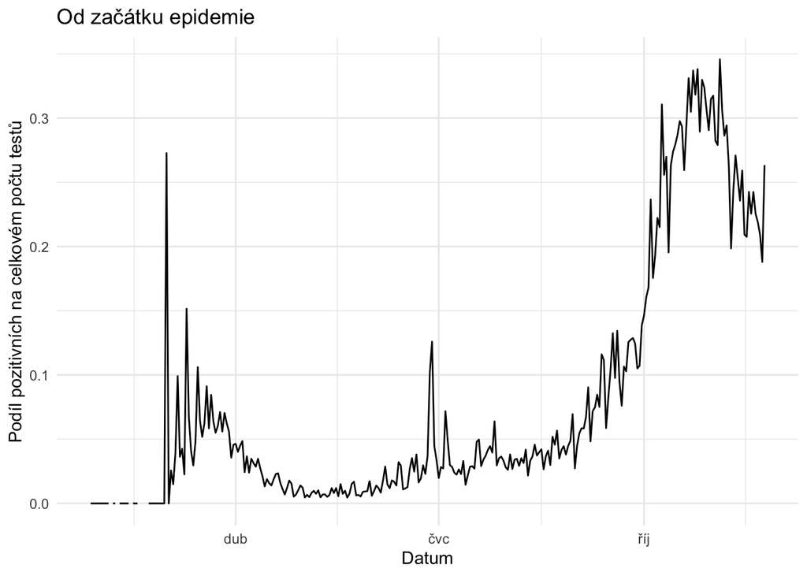

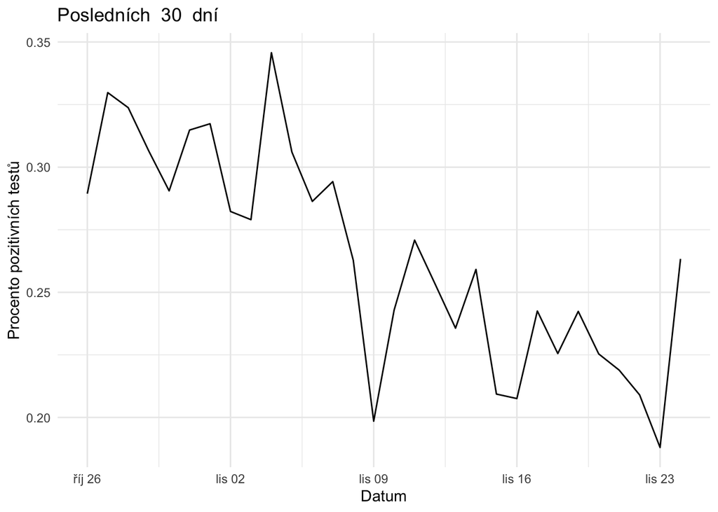

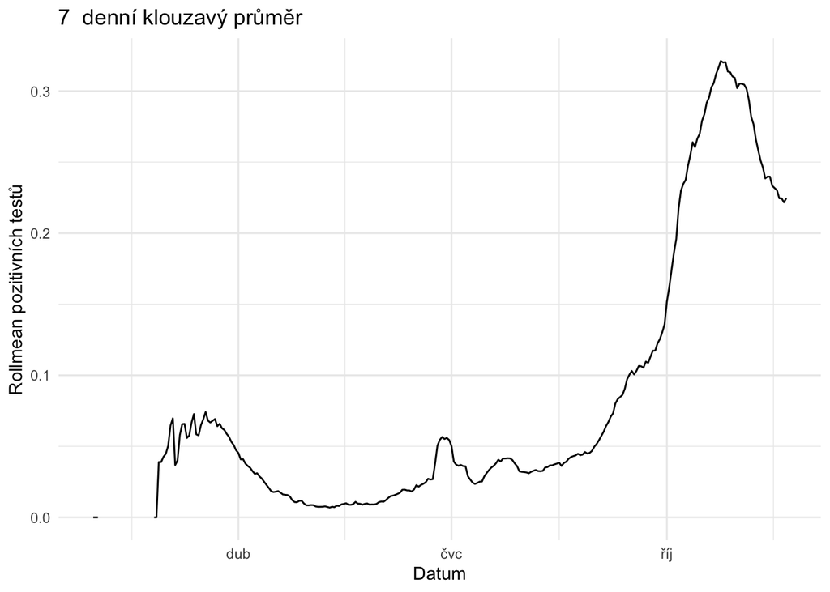

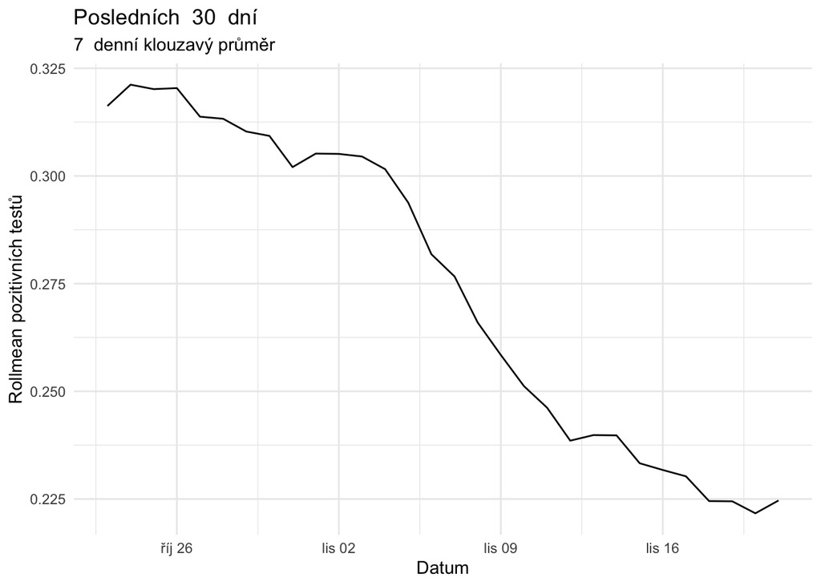

Podíl pozitivních testů na celkovém počtu od začátku epidemie je `16.883` %.

Podíl pozitivních testů na celkovém počtu za posledních 30 dní je `27.449` %.

# Modely

## Linearní model

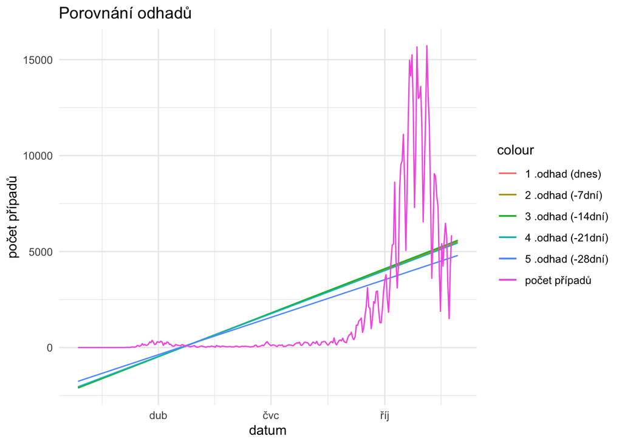

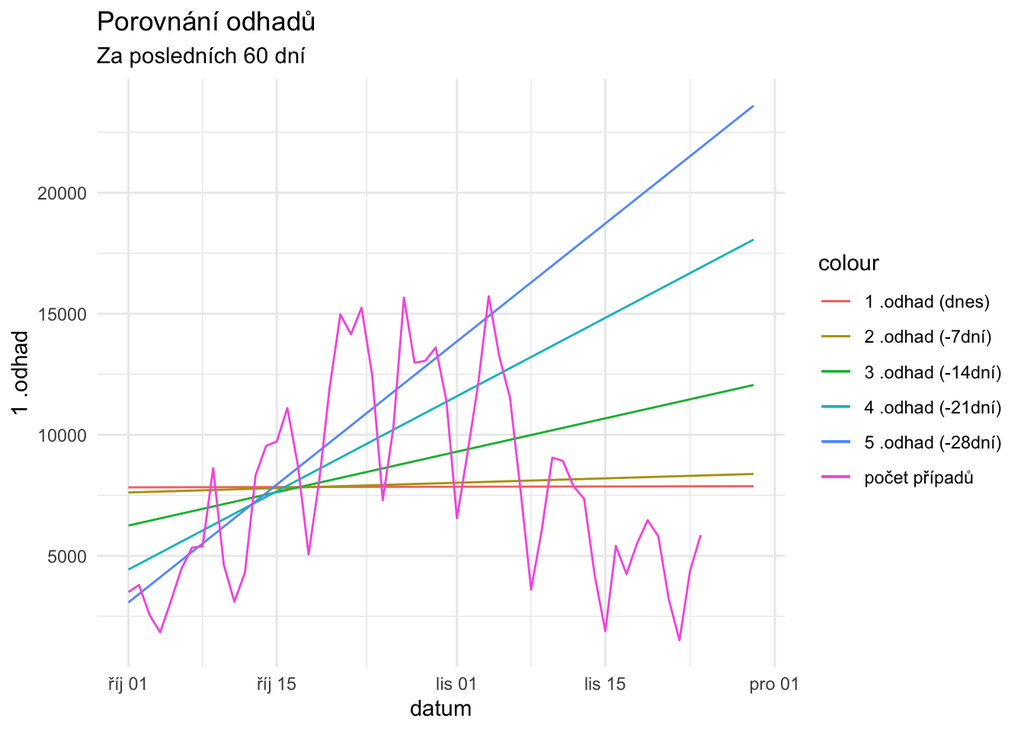

### Data (Lineární model)

#### Od začátku epidemie

Podle lineárního modelu bychom tímto tempem měli dne `2020-11-29` podle

- 1. odhadu `5512` nakažených denně
- 2. odhadu `5519` nakažených denně
- 3. odhadu `5591` nakažených denně
- 4. odhadu `5448` nakažených denně
- 5. odhadu `4797` nakažených denně

#### Za posledních `60` dní

Podle lineárního modelu bychom tímto tempem měli dne `2020-11-29` podle

- 1. odhadu `7877` nakažených denně
- 2. odhadu `8381` nakažených denně
- 3. odhadu `12057` nakažených denně
- 4. odhadu `18065` nakažených denně
- 5. odhadu `23597` nakažených denně

## Kvadratický model

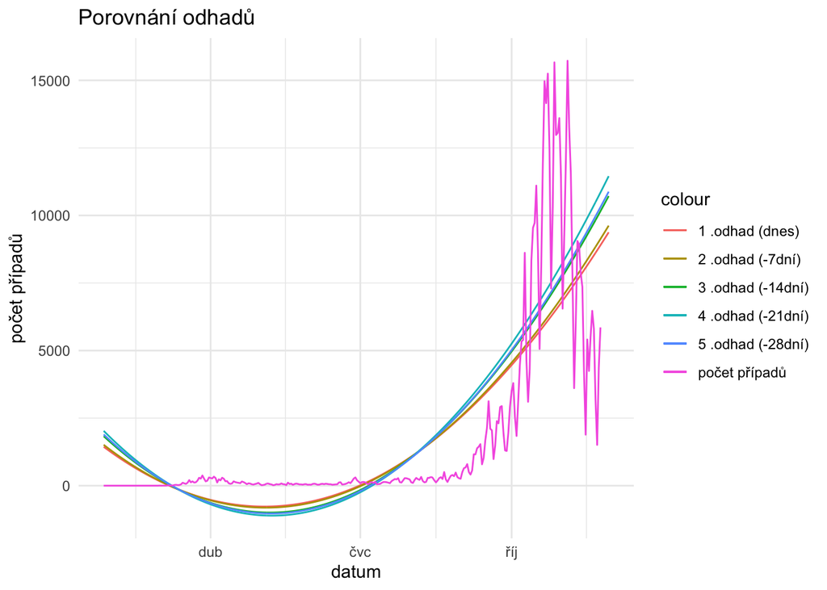

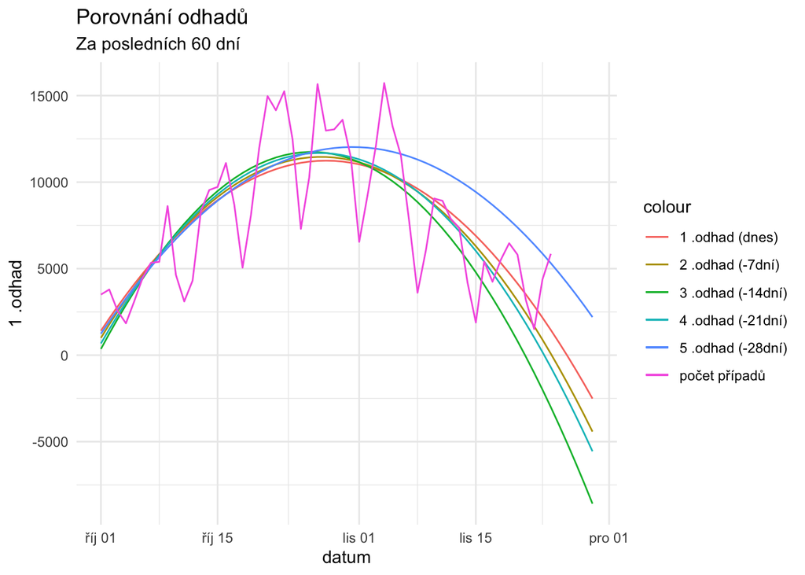

### Data (Kvadratický model)

#### Od začátku epidemie

Podle kvadratického modelu bychom tímto tempem měli dne `2020-11-29` podle

- 1. odhadu `9376` nakažených denně
- 2. odhadu `9622` nakažených denně
- 3. odhadu `10718` nakažených denně
- 4. odhadu `11454` nakažených denně
- 5. odhadu `10879` nakažených denně

#### Za posledních `60` dní

- 1. odhadu `-2510` nakažených denně
- 2. odhadu `-4418` nakažených denně
- 3. odhadu `-8583` nakažených denně
- 4. odhadu `-5555` nakažených denně
- 5. odhadu `2200` nakažených denně

## Exponential model

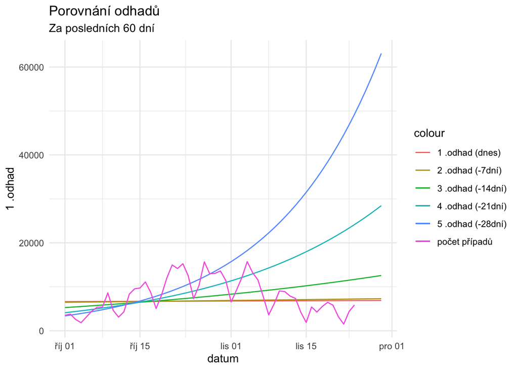

### Data (Exponential model)

#### Za posledních `60` dní

Podle exponencionálního modelu bychom tímto tempem měli dne `2020-11-29` podle

- 1. odhadu `6892` nakažených denně
- 2. odhadu `7286` nakažených denně
- 3. odhadu `12562` nakažených denně
- 4. odhadu `28452` nakažených denně
- 5. odhadu `63088` nakažených denně

Podle exponencionálního modelu bychom tímto tempem měli dnes dne `2020-11-25` podle

- 1. odhadu `6873` nakažených denně
- 2. odhadu `7228` nakažených denně
- 3. odhadu `11844` nakažených denně
- 4. odhadu `24951` nakažených denně
- 5. odhadu `51730` nakažených denně

# Informace

Update proběhl `2020-11-25 23:23:00`.

Poslední data jsou z `2020-11-24` ze stránek ministerstva zdravotnictví ČR (https://onemocneni-aktualne.mzcr.cz/covid-19)